# L08-1 Lab on Introduction to Regression

## Assignment Instructions

Rename with your name in place of Studentname and make your edits and updates here. Run each cell one at a time to make sure you understand what the code is doing.

You'll find 2 Your Turn prompts for exercises and questions to complete in this lab.

# Introduction to Regression

## Overview

This lesson introduces you to the basic principles of **regression models**. Regression models are **supervised machine learning** algorithms, which have the following properties:

- Are used to **predict a numereical value** or **score**.
- Map a set of **features** (**predictor** or **independent variable**) values to **predict** a **label** (**dependent variable**).
- Is a **supervised learning model**, meaning that the model is trained using **marked cases** with a known **label value**.
- Regression models minimize the error between the predicted **score** and the known **label**.
- Regression models can be **linear** or **nonlinear**.

Once you complete this lesson, you will be able to apply linear regression models to predict numeric values. Specifically, in this lesson you will explore the following topics:

- **Linear single regression** models, with one feature used to predict a label value.
- **Performance metrics and fit evaluation methods** used to evaluate regression models.
- **Determine if a model is overfit** and how to prune features to reduce overfit.
- **Transform features** to make them suitable for linear models.
- **Linear multiple regression** models, which use multiple features to predict the label value.

**Required packages** to run this notebook are:

- ggplot2
- dplyr

## Basics of Linear Regression

Let's have a look at the simplest case of a regression model for a straight line. Let's say that we are measuring two variables. For example, the first variable could be past customer spending and the other variable is the amount the customer spends in response to a coupon. We want to find a relationship between these variables so that we can predict the value of the second variable given a value of the first variable. In technical terms we want to **model** offer response based on a **predictor variable** of past spending.

Let's call the first variable $x$ or the **feature**. The features are the variables we use as the inputs to our predictive model. We will call the second variable $y$, or the **label**. The label is the variable we wish to **predict**.

The simplest linear regression model determines the equation of a straight line. We can write the **equation of a straight line** as follows:

$$Y = m X + b\\ where\\ slope = m = \frac{rise}{run}\\ and\\ y = b\ at\ x = 0\\ or\\ b = the\ intercecpt$$

We can illustrate this relationship as:

[figure not shown]

**A straight line**

We have a training data set with paired values, ${x_i,y_i}$. Using these training data we can define a line that best fits these data. If we have a number of values pairs, ${x_i,y_i}$, we can write the equation for the line, including errors as:

$$y_i = mx_i + b + \epsilon_i \\ where \\ \epsilon_i = error$$

We call the two parameters $m$ and $b$ the **model coefficients**.

We can visualize these errors, $\epsilon_i$, as shown in the figure below.

[figure not shown]

**Example of Least Squares Regression**

The question now is what do we mean by **the best fit** to the data? For most regression models we want to find the model which **minimizes the sum of the squared errors**. The errors are the difference between the **predicted values** or the **scored values**, and the **actual label values**. These errors are also known as **residuals**. This type of regression model is known as the **method of least squares**.

We want to solve for $m$ and $b$ by minimizing the error, $\epsilon_i$. We can write this out as follows.

$$min\ \Sigma_i \epsilon_i^2 = min\ \Sigma_i{ (y_i - \hat{y_i})^2} = min\ \Sigma\ errors\\ where\\ \hat{y_i} = mx_i + b = scored\ value$$

### A simple example

With this bit of theory behind us, let's look at a simple example.

The code in the cell below computes some synthetic data. The function in the code performs the following operations:

- A vector of Normally distributed noise with standard deviation, $sd$, is computed.
- A data frame is created with the uniformly spaced $x$ values and the $y$ values with the error added. Since $x_i = y_i$ the slop of the line is $1.0$.
- A **seed** for the random number generator is set to ensure this example is reproducible.

Execute this code and examine the head of the computed data frame.

```r
sim.data <- function(x1, y1, x2, y2, n, sd){
  error <- rnorm(n, mean = 0, sd = sd)
  data.frame(
              x = seq(from = x1, to = x2, length.out = n),
              y = (seq(from = y1, to = y2, length.out = n) + error)
            )
}
set.seed(1212)  # Set the random number seed so that the exercises are reproducible.
reg.data = sim.data(0, 0, 10, 10, 50, 1)
head(reg.data)
```

| x | y |
| --- | --- |
| 0.0000000 | -0.6290858 |
| 0.2040816 | 2.0415040 |
| 0.4081633 | 0.7518448 |
| 0.6122449 | -0.7478506 |
| 0.8163265 | 1.3521410 |
| 1.0204082 | 1.0576069 |

Next, let's use `ggplot2` to plot the data we just synthesized. The code in the cell below plots the values of the feature, $x$, and the label, $y$. Execute this code and examine the results.

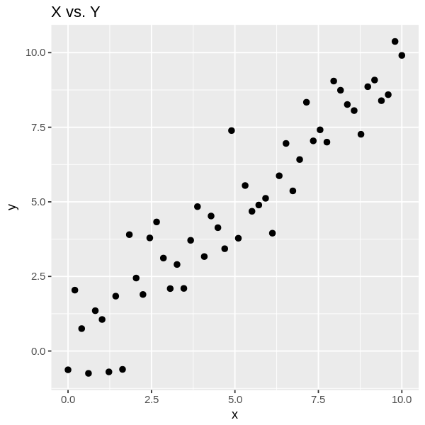

```r
require(repr)
options(repr.plot.width=5, repr.plot.height=5) ## set the plot area size
plot.dat <- function(df){
  require(ggplot2)
  ggplot(df, aes(x, y)) +
    geom_point(size = 2) +
    ggtitle('X vs. Y')
}
plot.dat(reg.data)
```

Models in R are defined by an equation using the $\sim$ symbol to mean modeled by. In summary, the variable to be modeled is always on the left. The relationship between the variabble to be modeled on the right. This basic scheme can be written as shown here.

$$dependent\ variable\sim indepenent\ variables\\ or\\ label \sim features\\ $$

In words, we say the symbol **$\sim$** as **is modeled by**. So the entire formula can be stated as **the label is modeled by the features**.

For example, for our data where we wish to model the $y$ variable by the $x$ variable, the R model formula is:

$$y \sim x$$

The R `lm` function computes a linear regression model using the model formula as the first argument. The `lm` function creates an **R model object** for a linear regression model. The model object contains a great deal of information which we will investigate in this lesson.

Once an R model object is computed, we can compute the **scores** or **predicted values** using the `predict` method. A **method** is a special type of function that uses the **attributes of an object**.

The code in the cell below compute the linear regression model for our synthetic data. This code does the following:

- Compute the R model object, `mod`, using the formula `y ~ x`.
- Use the model object to compute scores (predicted values) for the dependent variable `y`. In this case, we just use the data that was originally used to compute the model. In a more general case, you can use other data to make predictions from the model.
- The head of the data frame is printed.

Execute this code and examine the head of the data frame computed.

```r
mod = lm(y ~ x, data = reg.data)
reg.data$score <- predict(mod, data = reg.data)
head(reg.data, 10)
```

| x | y | score |
| --- | --- | --- |
| 0.0000000 | -0.6290858 | 0.04136302 |
| 0.2040816 | 2.0415040 | 0.23647536 |
| 0.4081633 | 0.7518448 | 0.43158770 |
| 0.6122449 | -0.7478506 | 0.62670005 |
| 0.8163265 | 1.3521410 | 0.82181239 |
| 1.0204082 | 1.0576069 | 1.01692473 |
| 1.2244898 | -0.6986292 | 1.21203708 |
| 1.4285714 | 1.8394511 | 1.40714942 |
| 1.6326531 | -0.6147274 | 1.60226176 |
| 1.8367347 | 3.9014529 | 1.79737410 |

The data frame shows the $x$ values, along with the true $y$ values, and the predicted values or `score`. You can see that the `score` values are generally close to the $y$ values.

### Examining regression results

Let's have a look at the predicted values or scores from our model and the data values we used to fit the model. The code in the cell below plots the original data, along with the predicted values shown as a line. Execute the code and examine the result.

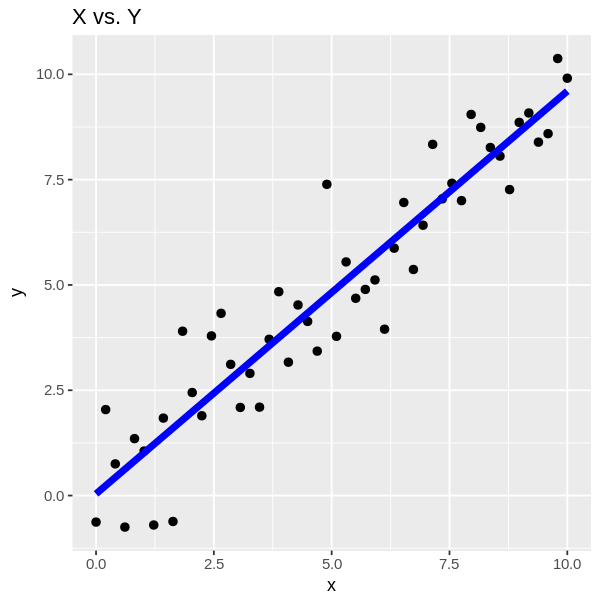

```r
plot.reg <- function(df){
  require(ggplot2)
  ggplot(df, aes(x, y)) +
    geom_point(size = 2) +
    geom_line(aes(x, score), size = 2, color = 'blue') +
    ggtitle('X vs. Y')
}
plot.reg(reg.data)
```

It appears that the model is a fairly good fit to the data we synthesized. We can further investigate the properties of our regression model by looking at the **model coefficients**.

The various **attributes** of the R model object are stored in an R list. The elements of this list can be accessed with the `$` operator. In this case, we want the model coefficients, which are called `coef` in the model object list. Execute the code in the cell below to print and examine the model coefficients.

```r
mod$coef
```

**(Intercept)**

0.0413630175907579

**x**

0.956050480296391

You can see the two model coefficients, one for the intercept ($b$ in our notation), and one for the slope, $x$ ($m$ in out notation). Using these coefficients we can predict new values of $\hat{y_i}$ with the formula:

$$\hat{y_i} = 0.0414 + 0.956\ x_i$$

In words, for every new value of $x$ we can predict a new values of $y$. Prediction is the essential purpose of a machine learning model of any kind.

### Visualizing regression results

In the foregoing section, we have seen that our linear regression model seems to work fairly well qualitatively. However, we need methods to quantitatively evaluate the performance and compare the performance of regression models.

As a first step, let's compute the **residuals** or errors for the model. The code in the cell below adds the residuals to the data frame and prints the head of the data frame. Execute this code and examine the label, $y$, the `score`, and the residuals.

```r
reg.data$resids <- reg.data$y - reg.data$score
head(reg.data, 10)
```

| x | y | score | resids |
| --- | --- | --- | --- |
| 0.0000000 | -0.6290858 | 0.04136302 | -0.67044882 |
| 0.2040816 | 2.0415040 | 0.23647536 | 1.80502869 |
| 0.4081633 | 0.7518448 | 0.43158770 | 0.32025707 |
| 0.6122449 | -0.7478506 | 0.62670005 | -1.37455068 |
| 0.8163265 | 1.3521410 | 0.82181239 | 0.53032864 |
| 1.0204082 | 1.0576069 | 1.01692473 | 0.04068217 |
| 1.2244898 | -0.6986292 | 1.21203708 | -1.91066626 |
| 1.4285714 | 1.8394511 | 1.40714942 | 0.43230172 |
| 1.6326531 | -0.6147274 | 1.60226176 | -2.21698920 |
| 1.8367347 | 3.9014529 | 1.79737410 | 2.10407884 |

You can see that the residuals have a wide range of value, both positive and negative.

Let's plot the residuals to examine their distribution properties. Ideally, the residuals from a linear regression model should have a **Normal distribution**.

**Note:** A common misconception is that the variables used for a linear model must have a Normal distribution. While, this condition makes obtaining a good fit easier, it is not a requirement. What is important is that the residuals have a Normal distribution.

We will make two plots:

- A **histogram** and **density estimation plot**, which show the distribution of the residuals.
- A **quantile-quantile Normal plot or qq-plot** which plots the quantiles of a standard Normal distribution on the $x$ axis and the quantiles of the residuals on the $y$ axis. Ideally, the points on the qq-plots should fall along a straight line. If the points fall close to a straight line, this indicates that the residuals are approximately Normal.

The code in the cell below plots the histogram and density estimation plot along side the qq-Normal plot. Execute this code and examine the distribution properties of the residuals.

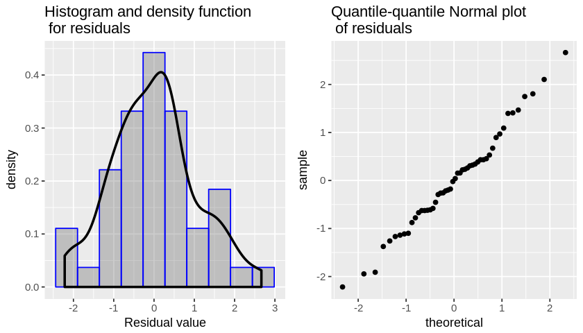

```r
plot.resids <- function(df){
  require(ggplot2)
  require(gridExtra)
  p1 = ggplot(df, aes(resids, ..density..)) +
         geom_histogram(bins = 10, alpha = 0.3, color = 'blue') +
         geom_density(size = 1) +
         xlab('Residual value') +
         ggtitle('Histogram and density function \n for residuals')
  p2 = ggplot(df, aes(sample = resids)) +
         geom_qq() +
         ggtitle('Quantile-quantile Normal plot \n of residuals')
  grid.arrange(p1, p2, ncol = 2)
}
options(repr.plot.width=7, repr.plot.height=4) ## set the plot area size
plot.resids(reg.data)
```

The histogram and density plot show that the residuals are approximately Normally distributed, with a few deviations. The points on the qq-Normal plot fall close to a straight line, indicating that the distribution of the residuals are close to Normal.

An important diagnostic is to check if the residuals are **homoscedastic** with respect to the fitted or scored values. By homoscedastic, we mean that the distribution of the residuals is constant with the fitted values. This condition indicates the regression model is a good fit, since the model error should not depend on the fitted value.

However, if there is structure in the residuals when plotted against the fitted values, we can infer that there is some kind of problem with the regression model. We call this condition **heteroscedastic** residuals. Heteroscedastic residuals indicate the model is not a good fit.

The code in the cell below plots the residuals vs. the fitted values for our regression model. A nonlinear regression, known as `loess`, is used to highlight the fit between the residuals and the fitted values. Execute this code and examine the results.

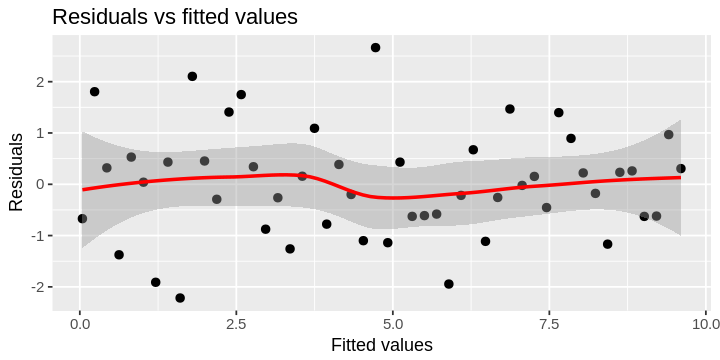

```r
scatter.resids <- function(df){
  require(ggplot2)
  ggplot(df, aes(score, resids)) +
    geom_point(size = 2) +
    geom_smooth(size = 1, color = 'red') +
    ggtitle('Residuals vs fitted values') +
    xlab('Fitted values') + ylab('Residuals')
}
options(repr.plot.width=6, repr.plot.height=3) ## set the plot area size
scatter.resids(reg.data)
```

Examine the plot you just created. Notice that the residuals have a fairly constant distribution with respect to the fitted values. Also, the `loess` line is close to 0 and nearly straight. These conditions indicate that the residuals are homoscedastic and our model is a good fit.

**Note:** The proper appearance of a plot of residuals vs. fitting values has been described as a 'fuzzy caterpillar'. The point being that the residuals should look rather random without much variation with respect to the fitted value.

**Note:** In this lesson we have used code developed specifically to plot the properties of our model residuals. The `plot` method for R model objects will create a plot of residuals vs. fitted values and a qq-Normal plot, along with some other useful diagnostic plots.

### Regression model statistics

We have looked at several possible diagnostic plots for the residuals of our linear model. There are also summary statistics we can look at to evaluate the performance of our model. The `summary` method prints a set of useful summary statistics. We will discuss the output of the `summary` method in the next few paragraphs.

When interpreting the output of the `summary` method and the confidence intervals, keep in mind that **overfitting** is a major problem with any machine learning model. Most of the output of the `summary` and `confint` methods help you to determine if a model is overfit.

The content of the `summary` output is as follows:

- The **call** used to compute the model being evaluate, which includes the model formula and the data frame used.
- **Quartiles**, minimum and maximum value of the residuals.
- Table of **model coefficients**, one for each feature in the model, plus the intercept if included. The figures in this table are used to determine if the coefficients are significant. Models with coefficients which are not significant are overfit. Each coefficient has the following statistics which are used to determine if coefficients are significant:
  - The **coefficient values** themselves.
  - The **standard error** of each model coefficient. If the standard error is of the same magnitude (or larger) than the coefficient value, the coefficient is not significant.
  - The **t value** and **p-value** for the hypothesis test on the model.
- The **residual standard error**. This figure should be reasonable given the scale of the label.
- The **R squared** and **adjusted R squared**. Adjusted R squared is adjusted for the degrees of freedom of the model and the residuals. You can think of adjusted R squared as a measure of the **reduction in variance** of the original lable value to the residuals from the model. A model which explains none of the variance has $adjusted\ R\ squared = 0$. A model with a perfect fit (*warning, may be over-fit*) has $adjusted\ R\ squared = 1.0$. We can write adjusted R squared as: $$R^2_{adj} = 1 - \frac{Var_{residual}}{Var_{initial}}$$
- Statistics on the significance of the overall model.

```r
summary(mod)
cat('The coefficient confidence intervals')
confint(mod)
```

```
Call:
lm(formula = y ~ x, data = reg.data)

Residuals:
     Min       1Q   Median       3Q      Max
-2.21699 -0.62615  0.00944  0.44852  2.66457

Coefficients:
            Estimate Std. Error t value Pr(>|t|)
(Intercept)  0.04136    0.29564    0.14    0.889
x            0.95605    0.05095   18.77   <2e-16 ***
---
Signif. codes:  0 ‘***’ 0.001 ‘**’ 0.01 ‘*’ 0.05 ‘.’ 0.1 ‘ ’ 1

Residual standard error: 1.061 on 48 degrees of freedom
Multiple R-squared:   0.88,	Adjusted R-squared:  0.8775
F-statistic: 352.1 on 1 and 48 DF,  p-value: < 2.2e-16
```

```
The coefficient confidence intervals
```

|  | 2.5 % | 97.5 % |
| --- | --- | --- |
| (Intercept) | -0.5530646 | 0.6357906 |
| x | 0.8536139 | 1.0584871 |

Examine these results and notice the following:

- The slope coefficient, $x$ is significant with a standard error significantly less that the coefficient value, a large t-value and small p-value. Further, the confidence intervals do not overlap with 0.0.
- However, the intercept coefficient is not significant since the standard error is larger than the coefficient value, t-value is small and p-value large. Further, the confidence interval includes 0.0.
- The fit appears reasonable, with an adjusted R squared of about 0.88.
- Overall the model is significant with a small p-value.

In summary, while the fit of this model may be reasonable, the model is over-fit.

# Your turn:

We have established that the initial model is over-fit. The question is, what to do about this problem. Since the intercept is the coefficient that is not significant, it makes sense to remove it from the model. You can delete the intercept term from an R model by adding $-1$ to the formula. The formula for our present model then becomes: $$y \sim x - 1$$ For this exercise compute a new model and print the `summary` and confidence interval for the coefficient using the above formula. In addition, make distribution, q-q Normal, and residual vs. fitted value plots. **Important; make sure you assign the new model to a new name**.

```r
# New Model with Intercept removed

my_mod = lm(y ~ x - 1, data = reg.data)
reg.data$score <- predict(my_mod, data = reg.data)
head(reg.data, 10)
```

| x | y | score | resids |
| --- | --- | --- | --- |
| 0.0000000 | -0.6290858 | 0.0000000 | -0.67044882 |
| 0.2040816 | 2.0415040 | 0.1963658 | 1.80502869 |
| 0.4081633 | 0.7518448 | 0.3927315 | 0.32025707 |
| 0.6122449 | -0.7478506 | 0.5890973 | -1.37455068 |
| 0.8163265 | 1.3521410 | 0.7854631 | 0.53032864 |
| 1.0204082 | 1.0576069 | 0.9818288 | 0.04068217 |
| 1.2244898 | -0.6986292 | 1.1781946 | -1.91066626 |
| 1.4285714 | 1.8394511 | 1.3745604 | 0.43230172 |
| 1.6326531 | -0.6147274 | 1.5709261 | -2.21698920 |
| 1.8367347 | 3.9014529 | 1.7672919 | 2.10407884 |

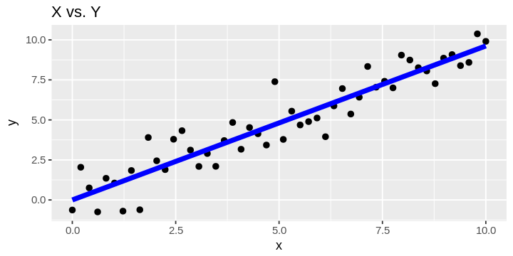

```r
# Distribution

plot.reg <- function(df){
  require(ggplot2)
  ggplot(df, aes(x, y)) +
    geom_point(size = 2) +
    geom_line(aes(x, score), size = 2, color = 'blue') +
    ggtitle('X vs. Y')
}
plot.reg(reg.data)
```

```r
reg.data$resids <- reg.data$y - reg.data$score
head(reg.data, 10)
```

| x | y | score | resids |
| --- | --- | --- | --- |
| 0.0000000 | -0.6290858 | 0.0000000 | -0.62908580 |
| 0.2040816 | 2.0415040 | 0.1963658 | 1.84513828 |
| 0.4081633 | 0.7518448 | 0.3927315 | 0.35911324 |
| 0.6122449 | -0.7478506 | 0.5890973 | -1.33694794 |
| 0.8163265 | 1.3521410 | 0.7854631 | 0.56667796 |
| 1.0204082 | 1.0576069 | 0.9818288 | 0.07577806 |
| 1.2244898 | -0.6986292 | 1.1781946 | -1.87682379 |
| 1.4285714 | 1.8394511 | 1.3745604 | 0.46489076 |
| 1.6326531 | -0.6147274 | 1.5709261 | -2.18565358 |
| 1.8367347 | 3.9014529 | 1.7672919 | 2.13416104 |

```r
# Coefficients
my_mod$coef
```

**x:** 0.962192261696231

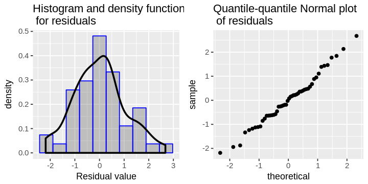

```r
plot.resids(reg.data)
```

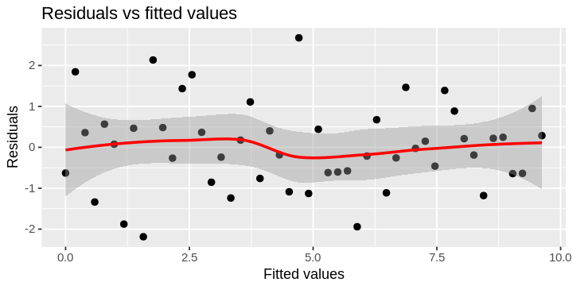

```r
scatter.resids(reg.data)
```

```r
summary(my_mod)
cat('The coefficient confidence intervals')
confint(my_mod)
```

```
Call:
lm(formula = y ~ x - 1, data = reg.data)

Residuals:
    Min      1Q  Median      3Q     Max
-2.1856 -0.6354  0.0251  0.4783  2.6759

Coefficients:
  Estimate Std. Error t value Pr(>|t|)
x   0.9622     0.0256   37.59   <2e-16 ***
---
Signif. codes:  0 ‘***’ 0.001 ‘**’ 0.01 ‘*’ 0.05 ‘.’ 0.1 ‘ ’ 1

Residual standard error: 1.05 on 49 degrees of freedom
Multiple R-squared:  0.9665,	Adjusted R-squared:  0.9658
F-statistic:  1413 on 1 and 49 DF,  p-value: < 2.2e-16
```

```
The coefficient confidence intervals
```

|  | 2.5 % | 97.5 % |
| --- | --- | --- |
| x | 0.9107536 | 1.013631 |

### Questions

Examine these results and answer the following questions:

1. Is the new model over-fit? If not, why not?
2. Is the fit of this model better or worse than the initial model?
3. Do the plots show evidence that the behavior of the residuals is better, worse, or about the same, when compared to the initial model?

### Answers

1.

2.

3.

## Multivariate Regression Models

The model we created and evaluated in the foregoing example, was univariate or a **single regression model**. There is only one predictor or feature in a single regression model. However, most real-world regression problems have multiple features which can be used to train the model and predict the label. We call these models **multivariate regression models** or **multiple regression models**.

The extension from single regression to multiple regression is conceptually simple. As we add more features we add more model coefficients, one for each new feature. All of the model coefficients are estimated using **the method of least squared errors**. This is the same approach we used for our single regression model.

The R formula language is easily extended to multiple regression problems. For example, if we wish to predict a feature, `dv`, using two features, `var1` and `var2`, the model formula will be:

$$dv \sim var1 + var2$$

### Multiple regression example.

Let's try an example of predicting the price of cars using an auto price data set. The data set contains the price of about 200 cars along with 25 attributes of each car.

**Note:** This data set is from the [University of California Irving Machine Learning Repository](https://archive.ics.uci.edu/ml/datasets/Automobile) The data was compiled by Jeffrey C. Schlimmer from the following sources:

- 1985 Model Import Car and Truck Specifications, 1985 Ward's Automotive Yearbook.
- Personal Auto Manuals, Insurance Services Office, 160 Water Street, New York, NY 10038
- Insurance Collision Report, Insurance Institute for Highway Safety, Watergate 600, Washington, DC 20037

As a first step we let's read the data from the raw `.csv` file. The function below reads and prepares the data for exploration and analysis. Some data munging is required to prepare these data including:

1. The `.csv` file is read, with attention to the possible coding used for missing values in the raw file. Notice that several possible codings for missing values are enabled.
2. Replace the `-` character in the column names with `.`. The `-` character in a column name causes problems with R naming conventions.
3. Remove two unneeded columns and cases with missing data from the data frame using a dpyr verb pipeline. These verbs are chained by the %>% operator.

```r
require(tidyverse)
read.auto = function(file = 'Automobile price data _Raw_.csv'){
    require(stringr)
    ## Read the raw csv file
    auto.price = read_csv(file, col_names = TRUE, na = c('?', '', NA))
    ## remove the '-' character from the column names
    names(auto.price) = str_replace_all(names(auto.price), '-', '.')
    ## Remove unwanted columns
    auto.price = auto.price %>%
                 select(-symboling, -normalized.losses)  %>%
                 filter(complete.cases(.))
    auto.price
}
auto.price = read.auto()
glimpse(auto.price)
```

```
combine(): dplyr, gridExtra
```

```
Observations: 193
Variables: 24
$ make              <chr> "alfa-romero", "alfa-romero", "alfa-romero", "aud...
$ fuel.type         <chr> "gas", "gas", "gas", "gas", "gas", "gas", "gas", ...
$ aspiration        <chr> "std", "std", "std", "std", "std", "std", "std", ...
$ num.of.doors      <chr> "two", "two", "two", "four", "four", "two", "four...
$ body.style        <chr> "convertible", "convertible", "hatchback", "sedan...
$ drive.wheels      <chr> "rwd", "rwd", "rwd", "fwd", "4wd", "fwd", "fwd", ...
$ engine.location   <chr> "front", "front", "front", "front", "front", "fro...
$ wheel.base        <dbl> 88.6, 88.6, 94.5, 99.8, 99.4, 99.8, 105.8, 105.8,...
$ length            <dbl> 168.8, 168.8, 171.2, 176.6, 176.6, 177.3, 192.7, ...
$ width             <dbl> 64.1, 64.1, 65.5, 66.2, 66.4, 66.3, 71.4, 71.4, 7...
$ height            <dbl> 48.8, 48.8, 52.4, 54.3, 54.3, 53.1, 55.7, 55.7, 5...
$ curb.weight       <int> 2548, 2548, 2823, 2337, 2824, 2507, 2844, 2954, 3...
$ engine.type       <chr> "dohc", "dohc", "ohcv", "ohc", "ohc", "ohc", "ohc...
$ num.of.cylinders  <chr> "four", "four", "six", "four", "five", "five", "f...
$ engine.size       <int> 130, 130, 152, 109, 136, 136, 136, 136, 131, 108,...
$ fuel.system       <chr> "mpfi", "mpfi", "mpfi", "mpfi", "mpfi", "mpfi", "...
$ bore              <dbl> 3.47, 3.47, 2.68, 3.19, 3.19, 3.19, 3.19, 3.19, 3...
$ stroke            <dbl> 2.68, 2.68, 3.47, 3.40, 3.40, 3.40, 3.40, 3.40, 3...
$ compression.ratio <dbl> 9.00, 9.00, 9.00, 10.00, 8.00, 8.50, 8.50, 8.50, ...
$ horsepower        <int> 111, 111, 154, 102, 115, 110, 110, 110, 140, 101,...
$ peak.rpm          <int> 5000, 5000, 5000, 5500, 5500, 5500, 5500, 5500, 5...
$ city.mpg          <int> 21, 21, 19, 24, 18, 19, 19, 19, 17, 23, 23, 21, 2...
$ highway.mpg       <int> 27, 27, 26, 30, 22, 25, 25, 25, 20, 29, 29, 28, 2...
$ price             <int> 13495, 16500, 16500, 13950, 17450, 15250, 17710, ...
```

Examine the column names and data types printed above. Along with the label, `price`, there are a number of features. Some of these features appear useful, whereas, other do not.

### Exploring the data set

In this lesson we will not dive deeply into the exploratory analysis of these data. We will only examine aspects of the features we need to create a multiple regression model.

Our first exploration is to look at the distribution of the label and some of the numeric features. The code in the cell below plots the histogram and density estimate for each feature specified.

**Code notes:** The use of ggplot2 here is fairly straight forward. The plot object is saved to the variable `p1`, and then printed explicitly. This allows the plots to still be displayed with `lapply` wrapped in `invisible`. The `invisible` function suppresses the printing of annoying list attributes. Notice that you could have any numeric column names list (vector). The `lapply` function iterates over this list, and calls `plot.hists` with each column name as the first argument.

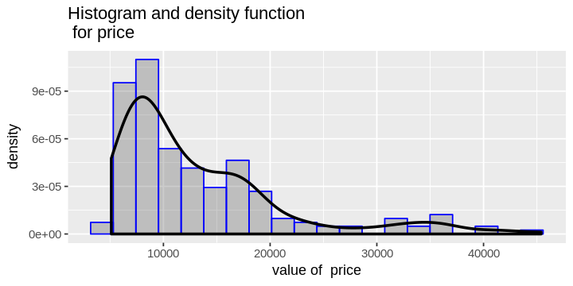

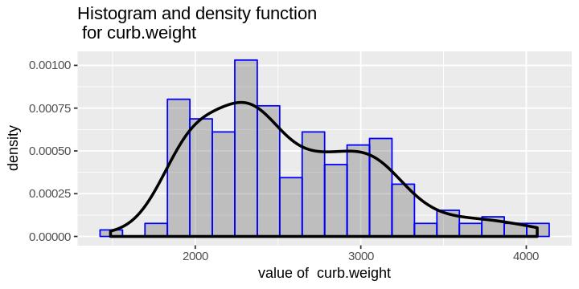

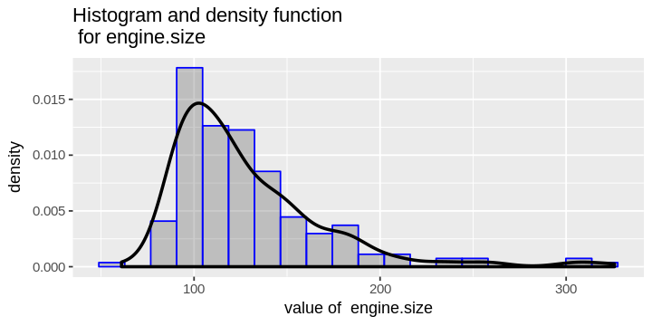

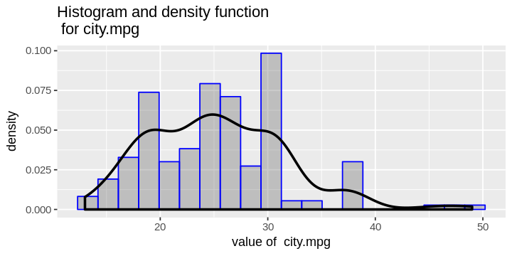

```r
plot.hists = function(col, df, bins = 20){
    require(ggplot2)
    p1 = ggplot(df, aes_string(col)) +
         geom_histogram(aes(y = ..density..), bins = bins,
                        alpha = 0.3, color = 'blue') +
         geom_density(size = 1) +
         xlab(paste('value of ', col)) +
         ggtitle(paste('Histogram and density function \n for', col))
    print(p1)
    }
cols = c('price', 'curb.weight', 'engine.size', 'city.mpg')
invisible(lapply(cols, plot.hists, auto.price))
```

### Preparing and transforming data

It is common practice to try various **transformations** of variables to find better distributional properties. Examples of these transformations include logarithms, square roots, squares, exponentiation, and other power transformations.

In this case, we will preform a log transformation on the price and engine size. We will also try a square root transformation of engine price. These transformations are performed by the code in the cell below. Execute this code to compute the transformations and visualize the results.

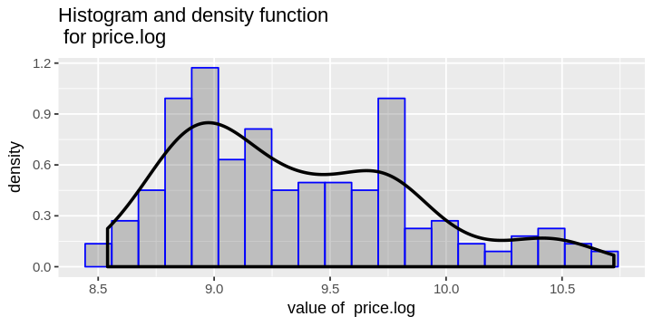

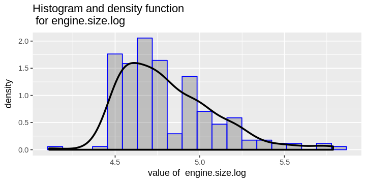

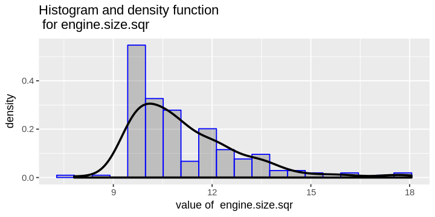

```r
auto.price = auto.price %>% mutate(price.log = log(price),
                                   engine.size.log = log(engine.size),
                                   engine.size.sqr = sqrt(engine.size),
                                   city.mpg.sqr = sqrt(city.mpg))
cols = c('price.log', 'engine.size.log', 'engine.size.sqr')
invisible(lapply(cols, plot.hists, auto.price))
```

Examine these results. None of these distributions are ideal, but notice the following:

1. The log transformation of the price has resulted in a more symmetric distribution.
2. The log transformation of engine size appears more symmetric than the square root transformation or the raw variable.

Next, let's briefly explore the relationship between some of these numeric features and the label, price. The code in the cell below creates plots for each of the features in the list vs. the log of price. Execute this code and examine the results.

**Programming note:** The code in the cell below is similar to the code you used to create the histograms. Compare this code with that used for the histograms, noticing the common recipe used for both.

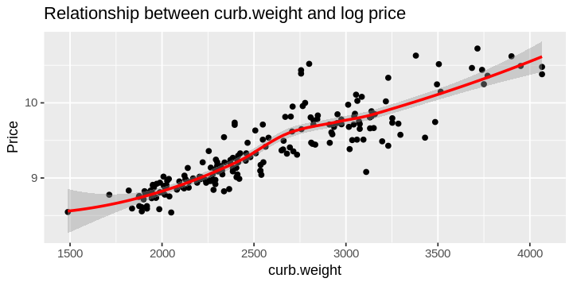

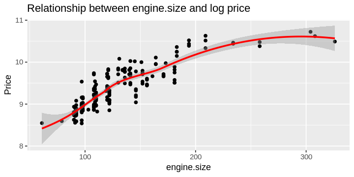

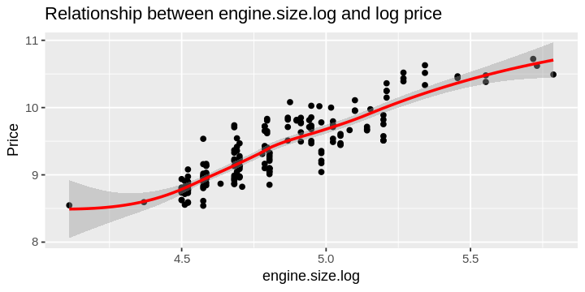

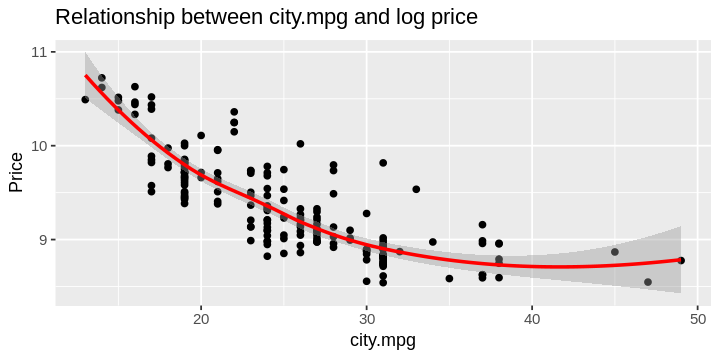

```r
plot.feature = function(col, df){
    p1 = ggplot(df, aes_string(x = col, y = 'price.log')) +
           geom_point() +
           geom_smooth(size = 1, color = 'red') +
           xlab(col) + ylab('Price') +
           ggtitle(paste('Relationship between', col, 'and log price'))
    print(p1)
}
cols = c('curb.weight', 'engine.size', 'engine.size.log', 'city.mpg')
invisible(lapply(cols, plot.feature, auto.price))
```

When examining these plots we are looking for a reasonably straight line relationship between the feature and the label, log price. Notice the following:

1. The relationship between log price and curb weight appears to be on a relatively straight line.
2. The relationship between log price and log of engine size appears to be closer to a straight line than the relationship with engine size.
3. The relationship between log price and city mpg is along a fairly straight line, but with some outliers which bends the curve at the high values of city mpg.

### Data normalization

Our next step is to **normalize** these numeric features. **Normalization is essential** whenever you are building a machine learning model with numeric features. If numeric features are not normalized the features with the largest numeric values can dominate the training of the model. In other words, the importance of features should not depend on the range of numeric values. Normalization addresses this problem.

In this case we will use a method known as **Zscore normalization**. Zscore normalization standardizes a feature so that it has **0 mean** and **unit (1.0) variance**. This process can be written for a feature vector, $x$, as:

$$x_{Zscore} = \frac{x - mean(x)}{sd(x)}\\ for\ a\ vector\ x$$

The code in the cell below Zscore normalizes the numeric features of interest. A square root transformation is also performed on the city mpg as well. Execute this code.

**Programming note:** The code below applies the dplyr `mutate` verb twice. Once to compute the square root of city mpg. And, once to apply the normalization function. These operators are chained by the `%>%` operator. It is necessary to chain these operators, since the `city.mpg.sqr` column must be added to the data frame before it can be normalized.

```r
normalize = function(x) (x - mean(x))/sd(x)
auto.price = auto.price %>% mutate(city.mpg.sqr = sqrt(city.mpg)) %>%
                            mutate(curb.weight = normalize(curb.weight),
                                   engine.size = normalize(engine.size),
                                   engine.size.log = normalize(engine.size.log),
                                   city.mpg = normalize(city.mpg),
                                   city.mpg.sqr = normalize(city.mpg.sqr))
```

Our data set has now been prepared for building a multivariate linear regression model.

Before we get started building a model, let's have a look at the transformed city mpg feature. Execute the code in the cell below to and examine the results.

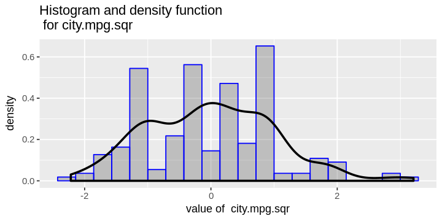

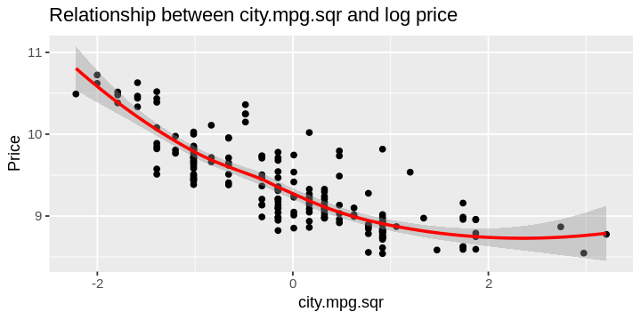

```r
plot.hists('city.mpg.sqr', auto.price)
plot.feature('city.mpg.sqr', auto.price)
```

Compare these plots to the ones produced earlier. The distribution of the square root of city mpg is a bit more symmetric. The curvature with respect to the log of price is not that noticeably different.

### Training the model

With the data prepared, we can now create a linear regression model. The code in the cell below computes a linear regression model using 5 numeric features, both raw and computed. Execute this code and examine the printed the summary of the model.

**Note:** We are constructing a **linear model**. However, we have included features with nonlinear transformations. Thus, just because we are using a linear model does not mean we are limited to models of straight lines.

```r
auto.mod = lm(price.log ~ curb.weight + engine.size + engine.size.log
              + city.mpg  + city.mpg.sqr, data = auto.price)
summary(auto.mod)
cat('The coefficient confidence intervals')
confint(auto.mod)
```

```
Call:
lm(formula = price.log ~ curb.weight + engine.size + engine.size.log +
    city.mpg + city.mpg.sqr, data = auto.price)

Residuals:
     Min       1Q   Median       3Q      Max
-0.52935 -0.11275 -0.00619  0.10100  0.59043

Coefficients:
                Estimate Std. Error t value Pr(>|t|)
(Intercept)      9.35148    0.01393 671.462  < 2e-16 ***
curb.weight      0.21358    0.03287   6.498 7.18e-10 ***
engine.size     -0.13723    0.08026  -1.710 0.088945 .
engine.size.log  0.27443    0.08880   3.091 0.002303 **
city.mpg         0.78602    0.20999   3.743 0.000242 ***
city.mpg.sqr    -0.91257    0.21795  -4.187 4.35e-05 ***
---
Signif. codes:  0 ‘***’ 0.001 ‘**’ 0.01 ‘*’ 0.05 ‘.’ 0.1 ‘ ’ 1

Residual standard error: 0.1935 on 187 degrees of freedom
Multiple R-squared:  0.8605,	Adjusted R-squared:  0.8567
F-statistic: 230.6 on 5 and 187 DF,  p-value: < 2.2e-16
```

```
The coefficient confidence intervals
```

|  | 2.5 % | 97.5 % |
| --- | --- | --- |
| (Intercept) | 9.32400360 | 9.37895221 |
| curb.weight | 0.14873821 | 0.27841718 |
| engine.size | -0.29555043 | 0.02109452 |
| engine.size.log | 0.09925717 | 0.44960542 |
| city.mpg | 0.37177507 | 1.20027394 |
| city.mpg.sqr | -1.34252903 | -0.48260919 |

Notice the following about these results:

1. The model appears to be **over-fit**, as the engine.size coefficient does not appear to be significant.
2. The residual standard error is reasonably small, given the range of label the log label values.
3. The adjusted R-squared is reasonable.
4. The model is significant.

### Evaluating model performance

Let's have a first look at the results of the model. The code in the cell below does the following using a dplyr operator chain:

- A first dplyr `mutate` operator computes the score using the `predict` method for the model.
- A second `mutate` operator in the chain computes the residuals and the predicted value on the non-log scale.
- The first 10 rows of the last 8 columns of the data frame are printed.

Execute this code and compare the label values to the predicted values, along with the (log) residual values.

```r
auto.price = auto.price %>% mutate(score = predict(auto.mod, data = auto.price)) %>%
                            mutate(resids = price.log - score,
                            predicted.price = exp(score))
auto.price[1:10, 24:31]
```

| price | price.log | engine.size.log | engine.size.sqr | city.mpg.sqr | score | resids | predicted.price |
| --- | --- | --- | --- | --- | --- | --- | --- |
| 13495 | 9.510075 | 0.2033875 | 11.40175 | -0.6572381 | 9.463035 | 0.04703977 | 12874.90 |
| 16500 | 9.711116 | 0.2033875 | 11.40175 | -0.6572381 | 9.463035 | 0.24808091 | 12874.90 |
| 16500 | 9.711116 | 0.7681683 | 12.32883 | -1.0148070 | 9.737158 | -0.02604202 | 16935.34 |
| 13950 | 9.543235 | -0.4330647 | 10.44031 | -0.1514361 | 9.179673 | 0.36356184 | 9697.98 |
| 17450 | 9.767095 | 0.3663794 | 11.66190 | -1.2006570 | 9.726643 | 0.04045242 | 16758.19 |
| 15250 | 9.632335 | 0.3663794 | 11.66190 | -1.0148070 | 9.551548 | 0.08078693 | 14066.45 |
| 17710 | 9.781885 | 0.3663794 | 11.66190 | -1.0148070 | 9.688202 | 0.09368284 | 16126.22 |
| 18920 | 9.847975 | 0.3663794 | 11.66190 | -1.0148070 | 9.732807 | 0.11516778 | 16861.82 |
| 23875 | 10.080587 | 0.2310686 | 11.44552 | -1.3917453 | 9.863579 | 0.21700827 | 19217.54 |
| 16430 | 9.706864 | -0.4663587 | 10.39230 | -0.3163281 | 9.224780 | 0.48208462 | 10145.44 |

Notice that for most cases the label (log label) values are close to the predicted (log predicted or score), and the residuals are small. In a few cases there are larger discrepancies and residuals.

The code in the cell below plots the (log) residuals. Execute this coded and examine the results.

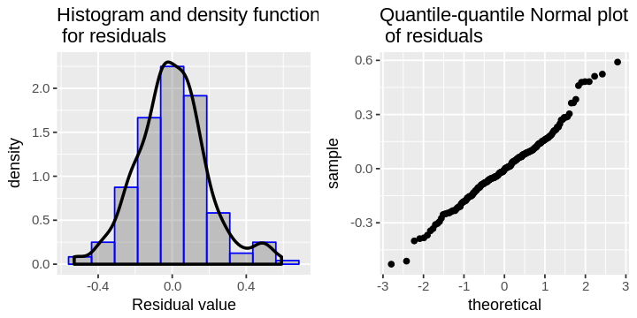

```r
plot.resids(auto.price)
```

Examine these results. Notice that the residuals have some deviation from the ideal Normal, paticularly at the high end. This means that the price of certain autos are being significantly underestimated.

The code of in the cell below plots the residuals vs. the fitted values. Execute this code and examine the results.

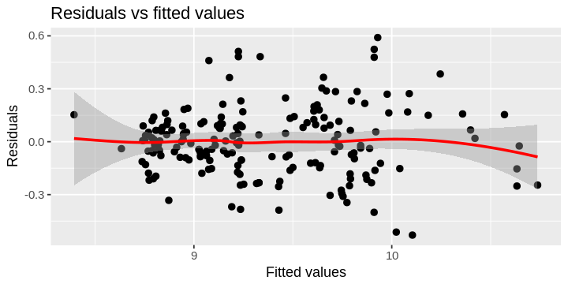

```r
scatter.resids(auto.price)
```

These residuals are appear fairly constant with the changes in (log) fitted values. The large positive residuals are visible in the middle of the range of fitted values. It appears that the predicted values of some higher priced cars are not being correctly predicted.

Overall, these results are not too bad, despite the over-fit model.